# Lab 3

Andrew Edelblum

1/30/2019

# 1. Start with the google_trends data.

## Visualize the change in trends for each hurricane over time in one plot with three scales. Map color to a discrete scale.

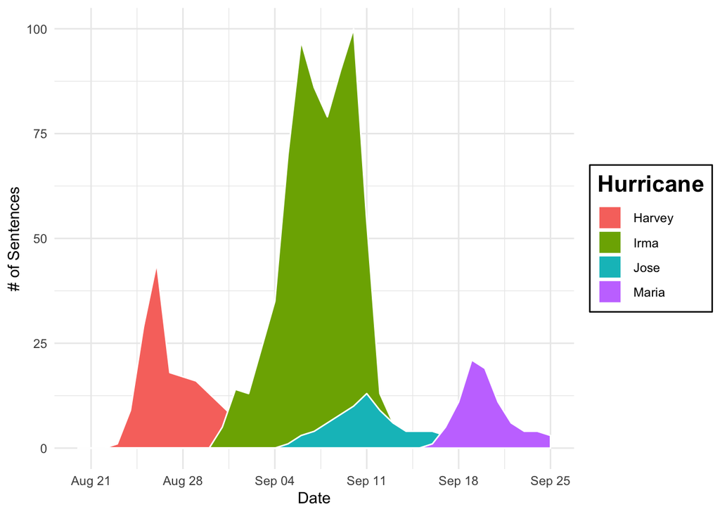

```r
google <- google_trends %>%
  gather("hurricane", "coverage", -1) %>%
  separate(hurricane, c("f1", "hurricane", "f2"), sep = "_") %>%
  select(-(starts_with("f")))

levels(google$hurricane) <- list("jose" = "Jose", "harvey" = "Harvey", "irma" = "Irma", "maria" = "Maria")

ggplot(google, aes(x = date, y = coverage, fill = hurricane)) +
  geom_density(stat = "identity", color = "white") +
  labs(x = "Date", y = "# of Sentences", fill = "Hurricane") +
  theme(legend.title = element_text(size = 16, face = "bold"),
        legend.background = element_rect(size = .5)) +
  scale_fill_discrete(labels = c("Harvey", "Irma", "Jose", "Maria"))
```

## Visualize the trends again, this time using geom_ribbon, setting the ymin to 0.

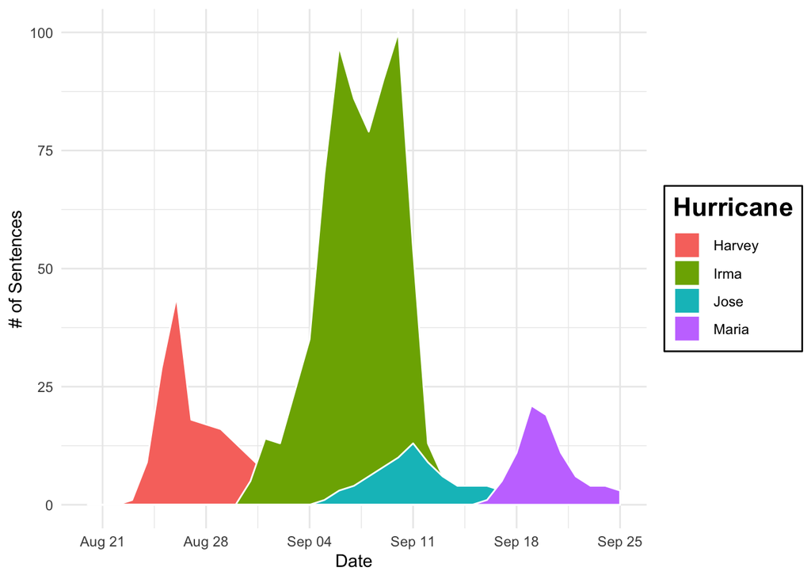

```r
ggplot(google, aes(x = date, y = coverage, fill = hurricane)) +
  geom_ribbon(aes(ymin = 0, ymax = coverage), color = "white") +
  labs(x = "Date", y = "# of Sentences", fill = "Hurricane") +
  theme(legend.title = element_text(size = 16, face = "bold"),
        legend.background = element_rect(size = .5)) +
  scale_fill_discrete(labels = c("Harvey", "Irma", "Jose", "Maria"))
```

## Visualize the same relation, but change the scales so color is mapped to a continuous scale.

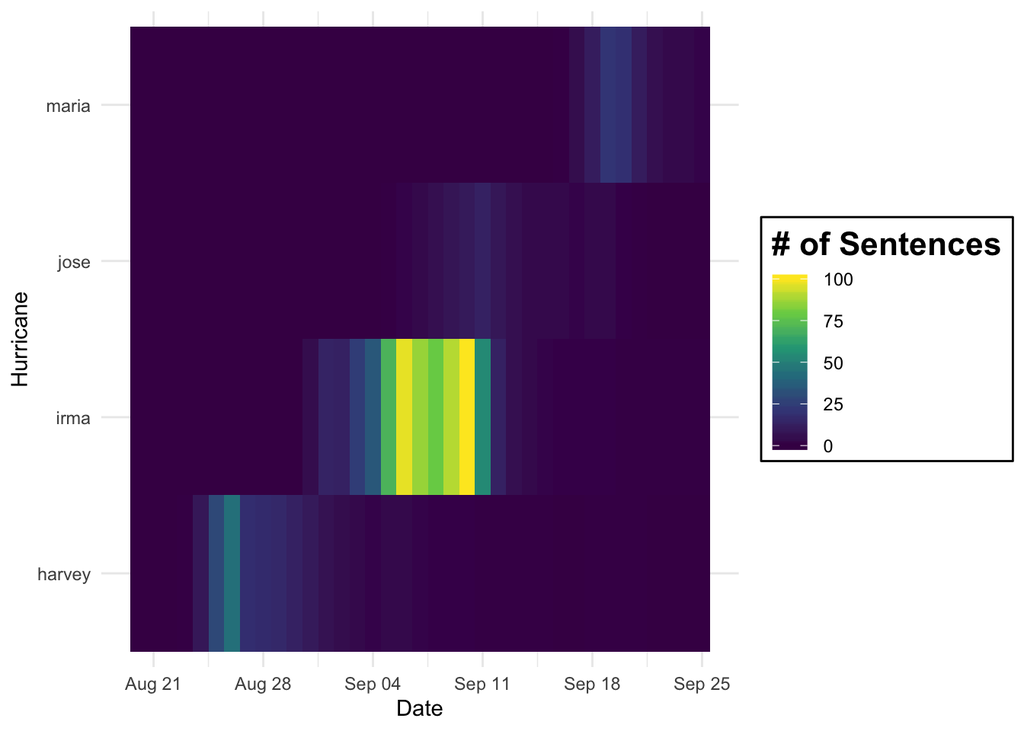

```r
ggplot(google, aes(x = date, y = hurricane, fill = coverage)) +
  geom_tile() +
  scale_color_continuous() +
  scale_fill_continuous(type = "viridis") +
  labs(x = "Date", y = "Hurricane", fill = "# of Sentences") +
  theme(legend.title = element_text(size = 16, face = "bold"),
        legend.background = element_rect(size = .5))
```

## Create a data frame that includes the dates that each hurricane made landfall. Annotate one of your first two plots to include these reference points with vertical lines. Make any final modifications to the plot you’d like to communicate the information as effectively as possible.

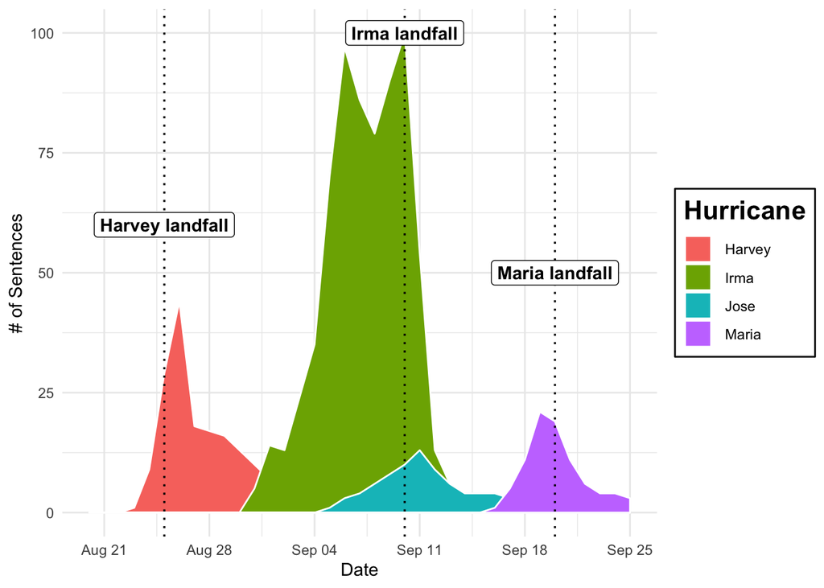

```r
library(lubridate)

landfall <- data.frame(hurricane = c("Harvey", "Irma", "Jose", "Maria", "Vegas"), date = mdy(c("August 25, 2017", "September 10, 2017", "NA", "September 20, 2017", "October 1, 2017")))

ggplot(google, aes(x = date, y = coverage, fill = hurricane)) +
  geom_ribbon(aes(ymin = 0, ymax = coverage), color = "white") +
  geom_vline(data = landfall, aes(xintercept = date), color = "black", linetype = "dotted", size = .6) +
  labs(x = "Date", y = "# of Sentences", fill = "Hurricane") +
  annotate("label", label = "Harvey landfall", x = as.Date("2017-08-25"), y = 60, color = "black", fontface = "bold") +
  annotate("label", label = "Irma landfall", x = as.Date("2017-09-10"), y = 100, color = "black", fontface = "bold") +
  annotate("label", label = "Maria landfall", x = as.Date("2017-09-20"), y = 50, color = "black", fontface = "bold") +
  theme(legend.title = element_text(size = 16, face = "bold"),
        legend.background = element_rect(size = .5)) +
  scale_fill_discrete(labels = c("Harvey", "Irma", "Jose", "Maria"))
```

# 2. Replicate the “National cable news networks” plot using the tv_states data. Don’t worry about all the labels. Try to match the colors, but don’t worry about getting them exact.

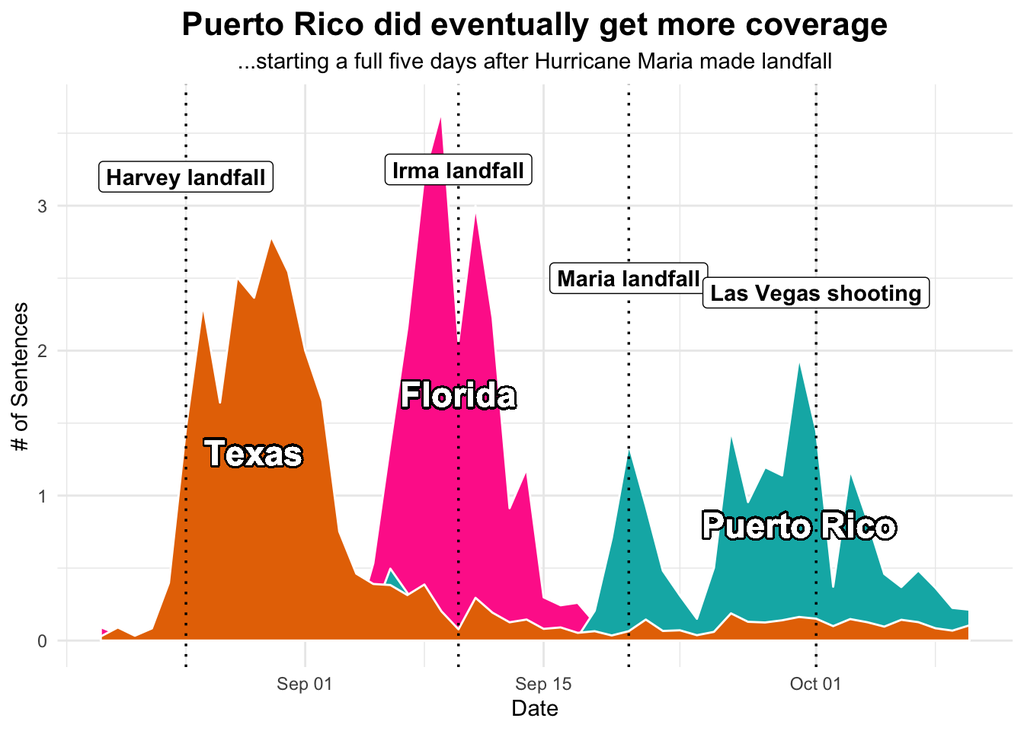

```r
library(shadowtext)

tv <- tv_states %>%
  gather("state", "sentences", -1)

ggplot(tv, aes(x = date, y = sentences, fill = state)) +
  geom_ribbon(aes(ymin = 0, ymax = sentences), color = "white") +
  geom_vline(data = landfall, aes(xintercept = date), color = "black", linetype = "dotted", size = .6) +
  labs(x = "Date", y = "# of Sentences", fill = "State", title = "Puerto Rico did eventually get more coverage", subtitle = "...starting a full five days after Hurricane Maria made landfall") +
  theme(legend.title = element_text(size = 16, face = "bold"),
        legend.background = element_rect(size = .5)) +
  scale_fill_manual(labels = c("Florida", "Puerto Rico", "Texas"), values = c("#ff3399", "#00b3b3", "#e67300")) +
  annotate("label", label = "Harvey landfall", x = as.Date("2017-08-25"), y = 3.2, color = "black", fontface = "bold") +
  annotate("label", label = "Irma landfall", x = as.Date("2017-09-10"), y = 3.25, color = "black", fontface = "bold") +
  annotate("label", label = "Maria landfall", x = as.Date("2017-09-20"), y = 2.5, color = "black", fontface = "bold") +
  annotate("label", label = "Las Vegas shooting", x = as.Date("2017-10-01"), y = 2.4, color = "black", fontface = "bold") +
  geom_shadowtext(label = "Texas", x = as.Date("2017-08-29"), y = 1.3, fontface = "bold", size = 6) +
  geom_shadowtext(label = "Florida", x = as.Date("2017-09-10"), y = 1.7, fontface = "bold", size = 6) +
  geom_shadowtext(label = "Puerto Rico", x = as.Date("2017-09-30"), y = 0.8, fontface = "bold", size = 6) +
  theme(legend.position = "none", plot.title = element_text(size = 16, face = "bold", hjust = 0.5), plot.subtitle = element_text(hjust = 0.5))
```

# 3. Use the comic_characters dataset to visualize the proportion of different genders using at least three different methods. With your final visualization, make any additional modifications you think would help reduce the cognitive load neccessary to comprehend the figure.

```r
comic <- comic_characters

comic_gen <- comic %>%
  select(align, sex) %>%
  group_by(sex) %>%
  summarize(count = n(),
            perc = (count/23272) * 100) %>%
  na.omit()
```

### Method 1

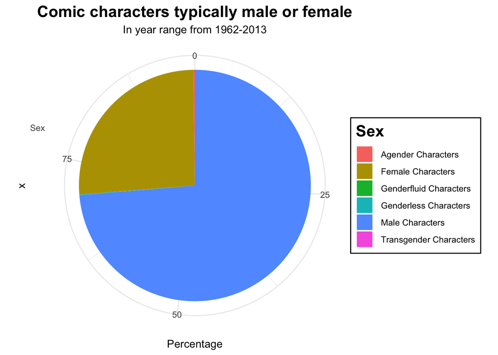

```r
ggplot(comic_gen, aes(x = "Sex", y = perc, fill = sex)) +
  geom_bar(stat = "identity") +
  coord_polar("y", start = 0) +
  labs(y = "Percentage", fill = "Sex", title = "Comic characters typically male or female", subtitle = "In year range from 1962-2013") +
  theme(legend.title = element_text(size = 16, face = "bold"),
        legend.background = element_rect(size = .5)) +
  theme(plot.title = element_text(size = 16, face = "bold", hjust = 0.5), plot.subtitle = element_text(hjust = 0.5))
```

### Method 2

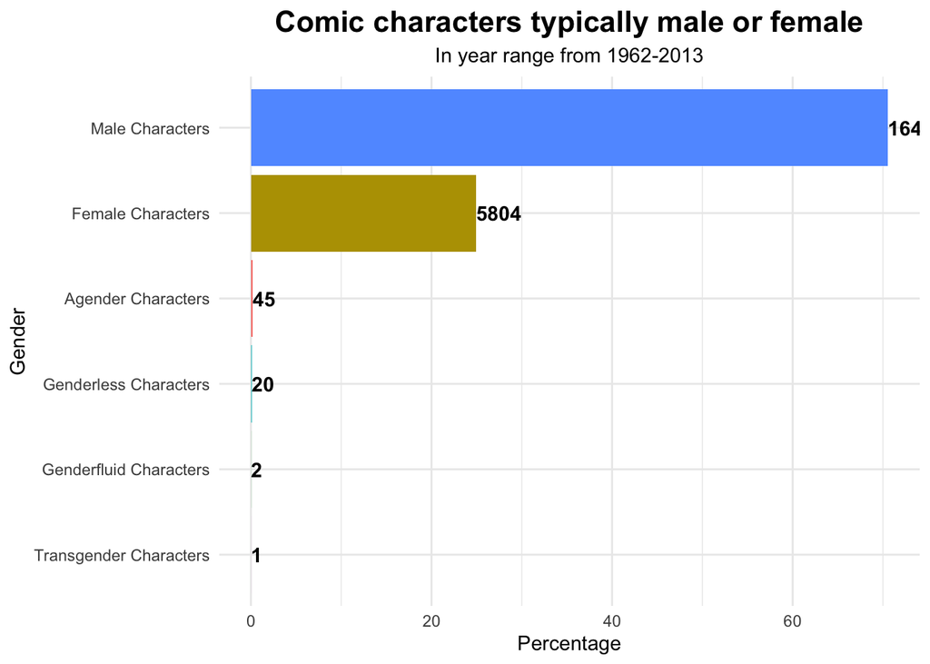

```r
ggplot(comic_gen, aes(x = reorder(sex, count), y = perc, fill = sex)) +
  geom_bar(stat = "identity") +
  coord_flip() +
  theme(legend.position = "none") +
  geom_text(aes(label = count), hjust = 0, fontface = "bold") +
  labs(x = "Gender", y = "Percentage", fill = "Sex", title = "Comic characters typically male or female", subtitle = "In year range from 1962-2013") +
  theme(legend.title = element_text(size = 16, face = "bold"),
        legend.background = element_rect(size = .5)) +
  theme(plot.title = element_text(size = 16, face = "bold", hjust = 0.5), plot.subtitle = element_text(hjust = 0.5))
```

### Method 3

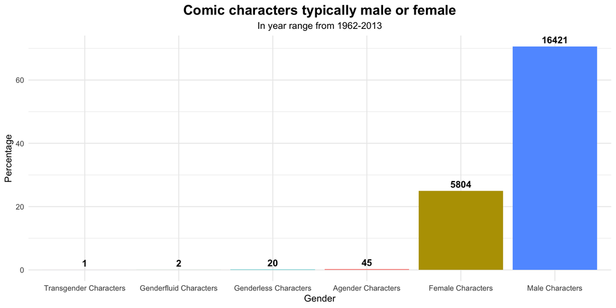

```r
ggplot(comic_gen, aes(x = reorder(sex, count), y = perc, fill = sex)) +
  geom_bar(stat = "identity") +
  theme(legend.position = "none") +
  geom_text(aes(label = count), vjust = -.5, fontface = "bold") +
  labs(x = "Gender", y = "Percentage", fill = "Sex", title = "Comic characters typically male or female", subtitle = "In year range from 1962-2013") +
  theme(legend.title = element_text(size = 16, face = "bold"),
        legend.background = element_rect(size = .5)) +
  theme(plot.title = element_text(size = 16, face = "bold", hjust = 0.5), plot.subtitle = element_text(hjust = 0.5))
```